Tarea 3. Análisis de supervivencia Jesus Rivera Cortez Noviembre/2022

# Problema 1. (Regresión Cox, Aditivos, BJ)

Considere los datos del ensayo Prevención de eventos con inhibición de la enzima convertidora de angiotensina (PEACE). El objetivo del estudio fue evaluar si la terapia con inhibidores de la ECA, cuando se agrega a la terapia convencional moderna, reduciría la tasa de infarto de miocardio no fatal infarto, muerte por causas cardiovasculares o revascularización en pacientes de bajo riesgo con enfermedad arterial coronaria estable y función ventricular izquierda normal o ligeramente reducida. Los pacientes fueron aleatorizados desde noviembre de 1996 hasta junio de 2000 y fueron seguidos durante hasta 7 años (mediana, 4,8 años), hasta el 31 de diciembre de 2003. El estudio se realizó después de la aprobación de las juntas de revisión institucional en 187 sitios en los Estados Unidos (incluido Puerto Rico), Canadá e Italia. Los pacientes dieron su consentimiento informado por escrito para participar. Una junta independiente de monitoreo de datos y seguridad revisó los datos de seguridad del paciente y resultados provisionales. Un comité de revisión de morbilidad y mortalidad revisó y clasificó todos resultados. Los datos consisten en las siguientes variables.

- **t2death**: time to death (months)
- **death**: censoring status (1=death; 0=censored)
- **tx**: 0=standard 1=treatment
- **age**: age(years) at baseline
- **sysbp**: systolic blood pressure at baseline
- **gender**: 1=female; 0=male
- **hidiabet**: history of diabetes (1=yes; 0=no) at baseline
- **hihypert**: history of hypertension (1=yes; 0=no) at baseline

Ajuste el modelo de riesgos proporcionales de Cox.

1. Obtenga los residuales para verificar si se cumple el supuesto de riegos proporcionales, puntos de influencia y datos atipicos. Verifique si es correcta la función de enlace exponencial. (Recuerde: Cox-snell, martingala, schoefied, devianza).

```r
#Ajuste del modelo
datos<- read.csv("C:/Users/Jesus/OneDrive/Documentos/supervivencia/peacedata.csv")
head(datos,20)
```

```
##     t2death death tx age sysbp gender hidiabet hihypert
## 1  53.91376     0  1  58   150      0        1        1
## 2  31.50719     1  0  68   144      0        0        1
## 3  53.58522     0  0  65   140      0        0        0
## 4  82.36550     0  0  64   184      0        0        1
## 5  42.15195     0  1  61   110      0        0        0
## 6  65.41273     0  0  57   132      0        0        1
## 7  65.08419     0  0  65   130      1        0        1
## 8  33.41273     0  1  68   132      0        0        0
## 9  41.88912     0  0  67   126      1        1        1
## 10 54.40657     0  1  65   142      0        0        1
## 11 53.84805     0  1  67   140      0        0        0
## 12 58.74333     0  0  60   108      0        0        0
## 13 72.04928     0  0  59   136      0        1        0
## 14 46.39014     0  1  69   130      0        0        1
## 15 41.13347     0  0  75   134      0        1        0
## 16 53.22382     0  0  70   140      0        0        0
## 17 77.66735     0  1  55   120      0        1        0
## 18 47.47433     0  1  56   128      0        0        0
## 19 53.97947     0  0  66   147      0        0        1
## 20 52.92813     0  1  80   140      0        0        1
```

```r
attach(datos)
datos2<- within(datos,{tx <- factor(tx)},{gender<-factor(gender)},
                {hidiabet<-factor(hidiabet)}, {hihypert<-factor(hihypert)})
attach(datos2)
library(survival)
model_cox<-coxph(Surv(t2death,death)~(tx)+age+sysbp+gender+hidiabet+hihypert,data=datos2)
summary(model_cox)
```

```
## Call:
## coxph(formula = Surv(t2death, death) ~ (tx) + age + sysbp + gender +
##     hidiabet + hihypert, data = datos2)
##
##   n= 8283, number of events= 633
##
##               coef exp(coef)  se(coef)      z Pr(>|z|)
## tx1      -0.134340  0.874293  0.079653 -1.687  0.09169 .
## age       0.070440  1.072980  0.005126 13.742  < 2e-16 ***
## sysbp     0.001197  1.001198  0.002443  0.490  0.62420
## gender   -0.348111  0.706020  0.109784 -3.171  0.00152 **
## hidiabet  0.565512  1.760348  0.091506  6.180 6.41e-10 ***
## hihypert  0.221465  1.247903  0.082814  2.674  0.00749 **
## ---
## Signif. codes:  0 '***' 0.001 '**' 0.01 '*' 0.05 '.' 0.1 ' ' 1
##
##          exp(coef) exp(-coef) lower .95 upper .95
## tx1         0.8743     1.1438    0.7479    1.0220
## age         1.0730     0.9320    1.0623    1.0838
## sysbp       1.0012     0.9988    0.9964    1.0060
## gender      0.7060     1.4164    0.5693    0.8755
## hidiabet    1.7603     0.5681    1.4713    2.1061
## hihypert    1.2479     0.8013    1.0609    1.4678
##
## Concordance= 0.678  (se = 0.011 )
## Likelihood ratio test= 256.5  on 6 df,   p=<2e-16
## Wald test            = 250.7  on 6 df,   p=<2e-16
## Score (logrank) test = 260.2  on 6 df,   p=<2e-16
```

```r
#Residuales
#Supuesto de riesgos proporcionales
#http://www.sthda.com/english/wiki/cox-model-assumptions#testing-proportional-hazards-assumption
test.ph <- cox.zph(model_cox)
test.ph
```

```
##             chisq df    p
## tx       1.55e+00  1 0.21
## age      4.48e-02  1 0.83
## sysbp    6.37e-01  1 0.42
## gender   2.17e+00  1 0.14
## hidiabet 4.06e-05  1 0.99
## hihypert 7.14e-04  1 0.98
## GLOBAL   4.67e+00  6 0.59
```

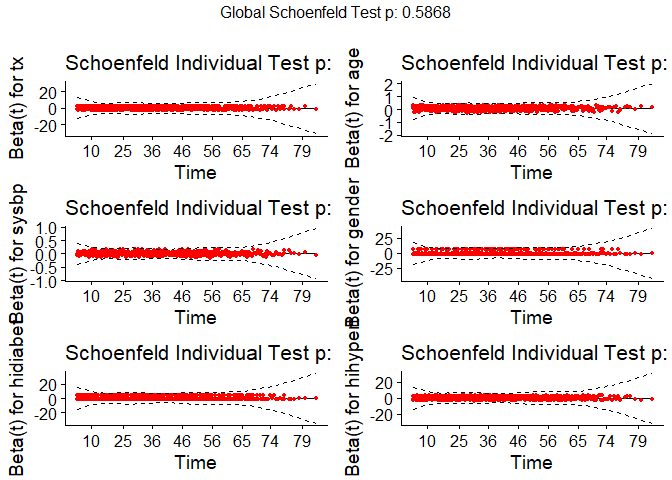

```r
library(survminer)
ggcoxzph(test.ph)
```

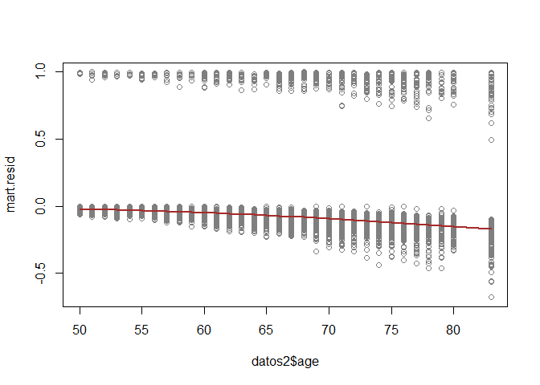

```r
#notas 8, pag. 8.
mart.resid = residuals(model_cox, type = "martingale")

plot(datos2$age, mart.resid, col="gray50")
lines(lowess(datos2$age, mart.resid), col = "brown", lwd=2)
```

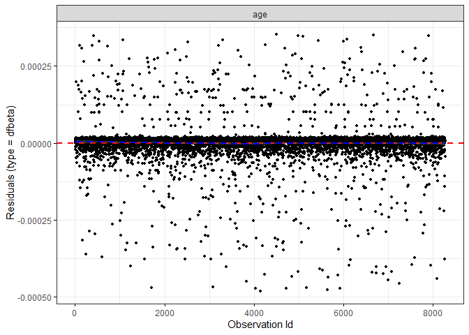

```r
#plot(datos2$tx, mart.resid, col="gray50")
#lines(lowess(datos2$tx, mart.resid), col = "brown", lwd=2)
#Puntos de influencia
model_cox<-coxph(Surv(t2death,death)~age,data=datos2)

ggcoxdiagnostics(model_cox, type = "dfbeta",
                 linear.predictions = FALSE, ggtheme = theme_bw())
```

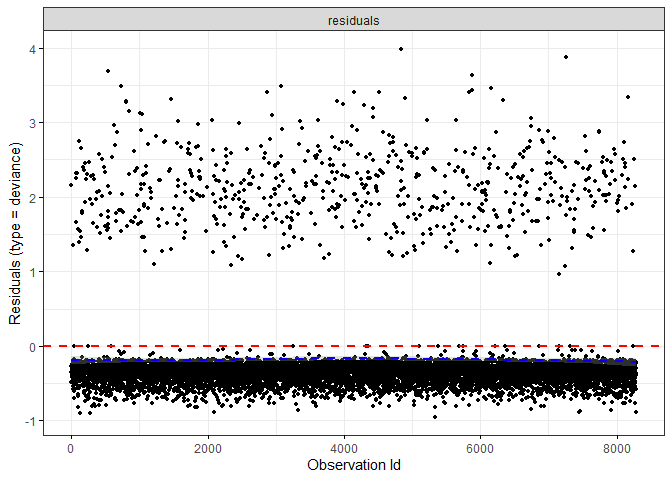

```r
#verificar datos atípicos
ggcoxdiagnostics(model_cox, type = "deviance",
                 linear.predictions = FALSE, ggtheme = theme_bw())
```

2. Ajuste el modelo de riesgos aditivos de Aalen y compare con Cox.

```r
#Modelo de riesgos aditivos de Aalen
#ver notas 9

Aalen_model<-aareg(Surv(t2death,death)~(tx)+age+sysbp+gender+hidiabet+hihypert,data=datos2)
summary(Aalen_model)
```

```
##               slope      coef se(coef)      z        p
## Intercept -7.01e-03 -5.49e-04 6.95e-05 -7.900 2.74e-15
## tx1       -1.77e-04 -2.03e-05 1.20e-05 -1.700 8.95e-02
## age        1.30e-04  1.04e-05 8.95e-07 11.600 2.59e-31
## sysbp      3.29e-06  1.13e-07 4.07e-07  0.278 7.81e-01
## gender    -7.52e-04 -5.21e-05 1.51e-05 -3.450 5.51e-04
## hidiabet   1.23e-03  9.88e-05 1.94e-05  5.090 3.51e-07
## hihypert   3.81e-04  3.22e-05 1.27e-05  2.530 1.14e-02
##
## Chisq=184.86 on 6 df, p=<2e-16; test weights=aalen
```

3. Ajuste el modelo de riesgos aditivos de Lin y compare.

```r
Lin_model<-aareg(Surv(t2death,death==1)~(tx)+age+sysbp+gender+hidiabet+hihypert,data=datos2)
summary(Lin_model)
```

```
##               slope      coef se(coef)      z        p
## Intercept -7.01e-03 -5.49e-04 6.95e-05 -7.900 2.74e-15
## tx1       -1.77e-04 -2.03e-05 1.20e-05 -1.700 8.95e-02
## age        1.30e-04  1.04e-05 8.95e-07 11.600 2.59e-31
## sysbp      3.29e-06  1.13e-07 4.07e-07  0.278 7.81e-01
## gender    -7.52e-04 -5.21e-05 1.51e-05 -3.450 5.51e-04
## hidiabet   1.23e-03  9.88e-05 1.94e-05  5.090 3.51e-07
## hihypert   3.81e-04  3.22e-05 1.27e-05  2.530 1.14e-02
##
## Chisq=184.86 on 6 df, p=<2e-16; test weights=aalen
```

4. Use el modelo de regresión de Buckley James para estos datos. Examine un gráfico de diagnóstico de los residuales vs frente a los valores ajustados violaciones al supuesto de varianza residual constante en el modelo.

```r
#bj(formula = Surv(time, status) ~ trt + karno + diagtime + age +prior, data = #veteran, link = "identity", method = "fit", x = T, y = T)
#install.packages("rms")
library(rms)
buckley_model<-bj(Surv(t2death,death)~tx+age+sysbp+gender+hidiabet+hihypert,data=datos2,link = "identity", method = "fit", x = T, y = T, control=list(iter.max=200))
buckley_model
```

```
## Buckley-James Censored Data Regression
##
##  bj(formula = Surv(t2death, death) ~ tx + age + sysbp + gender +
##      hidiabet + hihypert, data = datos2, link = "identity", control = list(iter.max = 200),
##      method = "fit", x = T, y = T)
##
##                                     Discrimination
##                                            Indexes
##  Obs    8283    Regression d.f.6    g       20.865
##  Events  633        sigma25.8457
##                     d.f.     626
##
##            Coef     S.E.    Wald Z Pr(>|Z|)
##  Intercept 249.8200 10.9167  22.88 <0.0001
##  tx=1        2.7735  2.0652   1.34 0.1793
##  age        -1.9574  0.1249 -15.67 <0.0001
##  sysbp      -0.0250  0.0607  -0.41 0.6799
##  gender     10.0027  2.8286   3.54 0.0004
##  hidiabet  -18.0528  2.3976  -7.53 <0.0001
##  hihypert   -7.1760  2.1509  -3.34 0.0008
##
```

```r
BIC(buckley_model)
```

```
## numeric(0)
```

```r
dd <- datadist(datos)
options(datadist="dd")
summary(buckley_model)
```

```
##              Effects              Response : Surv(t2death, death)
##
##  Factor   Low High Diff. Effect    S.E.   Lower 0.95 Upper 0.95
##  age       58  70  12    -23.48900 1.4993 -26.4270   -20.5500
##  sysbp    120 144  24     -0.60067 1.4559  -3.4541     2.2528
##  gender     0   1   1     10.00300 2.8286   4.4588    15.5470
##  hidiabet   0   1   1    -18.05300 2.3976 -22.7520   -13.3540
##  hihypert   0   1   1     -7.17600 2.1509 -11.3920    -2.9603
##  tx - 1:0   1   2  NA      2.77350 2.0652  -1.2742     6.8212
```

```r
dim(datos2)
```

```
## [1] 8283    8
```

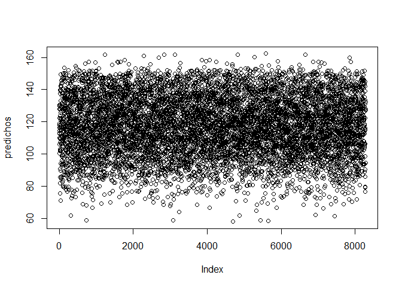

```r
predichos<-as.numeric(predict(buckley_model))
plot(predichos)
```

```r
residuales<-as.numeric(resid(buckley_model))
c(length(predichos),length(residuales) )
```

```
## [1]  8283 16566
```

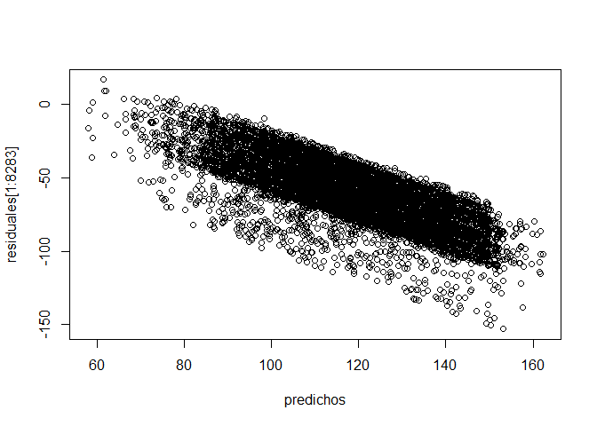

```r
#gráfica: https://search.r-project.org/CRAN/refmans/rms/html/bj.html
plot( predichos, residuales[1:8283])
```

```r
class(residuales)
```

```
## [1] "numeric"
```

```r
 #se viola el supuesto de homoscedasticidad
#r <- resid(buckley_model, 'censored.normalized')
#survplot(npsurv(r ~ 1), conf='none')
```

5. Que ventajas y desventajas observa en los modelos empleados?

bj tiene problemas de convergencia

# Problema 2. (AFT Regresion Weibull)

El conjunto de datos de la tabla está tomado de: Gertsbakh, I.B. (1989). Statistical Reliability Theory, Marcel Dekker, New York Proporciona los tiempos de vida útil para 40 motores probados a diferentes temperaturas. y condiciones de carga. El indicador de falla es uno cuando falla el motor y cero cuando todavía estaba funcionando al final de la prueba.

```r
fail_time <- c(5.45,5.74,5.8,6.37,6.49,6.91,7.02,7.1,7.1,7.1,5.07,5.19,5.22,
             5.58,5.83,6.09,6.25,6.3,6.3,6.3,5.15,6.11,6.11,6.23,6.28,6.32,
             6.41,6.56,6.61,6.9,3.53,4.22,4.73,5.22,5.46,5.58,5.61,5.97,
             6.02,6.1)
load <- c(rep(1,20), rep(-1,20))
temper <- c(rep(1, 10), rep(-1, 10), rep(1, 10), rep(-1, 10))
fail_ind <- c(rep(1, 7), c(0, 0, 0), rep(1, 7), c(0, 0, 0),
              rep(1, 9), 0, rep(1, 9), 0)
library(kableExtra)
dt=cbind(fail_time, load, temper, fail_ind)
dt %>%
  kbl(caption = "Tiempo de vida útil para 40 motores") %>%
  kable_classic(full_width = F, html_font = "Cambria")
```

Tiempo de vida útil para 40 motores

| fail_time | load | temper | fail_ind |
| --- | --- | --- | --- |
| 5.45 | 1 | 1 | 1 |
| 5.74 | 1 | 1 | 1 |
| 5.80 | 1 | 1 | 1 |
| 6.37 | 1 | 1 | 1 |
| 6.49 | 1 | 1 | 1 |
| 6.91 | 1 | 1 | 1 |
| 7.02 | 1 | 1 | 1 |
| 7.10 | 1 | 1 | 0 |
| 7.10 | 1 | 1 | 0 |
| 7.10 | 1 | 1 | 0 |
| 5.07 | 1 | -1 | 1 |
| 5.19 | 1 | -1 | 1 |
| 5.22 | 1 | -1 | 1 |
| 5.58 | 1 | -1 | 1 |
| 5.83 | 1 | -1 | 1 |
| 6.09 | 1 | -1 | 1 |
| 6.25 | 1 | -1 | 1 |
| 6.30 | 1 | -1 | 0 |
| 6.30 | 1 | -1 | 0 |
| 6.30 | 1 | -1 | 0 |
| 5.15 | -1 | 1 | 1 |
| 6.11 | -1 | 1 | 1 |
| 6.11 | -1 | 1 | 1 |
| 6.23 | -1 | 1 | 1 |
| 6.28 | -1 | 1 | 1 |
| 6.32 | -1 | 1 | 1 |
| 6.41 | -1 | 1 | 1 |
| 6.56 | -1 | 1 | 1 |
| 6.61 | -1 | 1 | 1 |
| 6.90 | -1 | 1 | 0 |
| 3.53 | -1 | -1 | 1 |
| 4.22 | -1 | -1 | 1 |
| 4.73 | -1 | -1 | 1 |
| 5.22 | -1 | -1 | 1 |
| 5.46 | -1 | -1 | 1 |
| 5.58 | -1 | -1 | 1 |
| 5.61 | -1 | -1 | 1 |
| 5.97 | -1 | -1 | 1 |
| 6.02 | -1 | -1 | 1 |
| 6.10 | -1 | -1 | 0 |

Las estimaciones de máxima verosimilitud para los coeficientes de regresión y el parámetro de escala fueron dados por Gertsbakh

```r
intercept<-6.318; Load_coef<-0.253; Temp_coef<-0.391;  scale<-0.539
fit<-cbind(intercept, Load_coef,Temp_coef,scale)
 fit %>% kbl(caption = "Estimaciones de máxima verosimilitud") %>%
  kable_classic(full_width = F, html_font = "Cambria")
```

Estimaciones de máxima verosimilitud

| intercept | Load_coef | Temp_coef | scale |
| --- | --- | --- | --- |
| 6.318 | 0.253 | 0.391 | 0.539 |

1. Ajuste un modelo de regresion AFT Weibull compare sus estimaciones con las dadas por autor.

```r
aft.fit <- survreg(Surv(exp(fail_time), fail_ind) ~load+temper,
                   dist = "weibull")
aft.fit
```

```
## Call:
## survreg(formula = Surv(exp(fail_time), fail_ind) ~ load + temper,
##     dist = "weibull")
##
## Coefficients:
## (Intercept)        load      temper
##   6.3168467   0.2528090   0.3909575
##
## Scale= 0.5384808
##
## Loglik(model)= -227   Loglik(intercept only)= -235.5
##  Chisq= 16.99 on 2 degrees of freedom, p= 0.000204
## n= 40
```

2. ¿Qué supuestos tiene el modelo? ¿Puede verificarlas?
- Existe el supuesto de que sigue una distribución Weibull y podemos probarlo de la siguiente manera

```r
library(SurvRegCensCov)
motor<-data.frame(exp.fail=exp(fail_time), fInd=fail_ind, load=factor(load),temper=factor(temper) )
attach(motor)
 diagnostico<-WeibullDiag(Surv(exp.fail, fInd) ~ load+temper, data=motor)
```

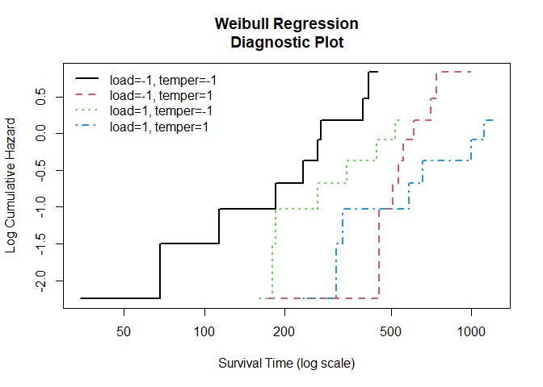

3. Suponga que deseamos usar otro modelo AFT, pruebe con Lognormal y log logistica. Compare verosimilitudes.
- Log-normal

```r
lognor.fit <- survreg(Surv(exp(fail_time), fail_ind) ~factor(load)+factor(temper),
                   dist = "lognormal")
lognor.fit
```

```
## Call:
## survreg(formula = Surv(exp(fail_time), fail_ind) ~ factor(load) +
##     factor(temper), dist = "lognormal")
##
## Coefficients:
##     (Intercept)   factor(load)1 factor(temper)1
##       5.3629364       0.5016627       0.8625608
##
## Scale= 0.721573
##
## Loglik(model)= -227.7   Loglik(intercept only)= -235
##  Chisq= 14.55 on 2 degrees of freedom, p= 0.000691
## n= 40
```

- Log_logistica

```r
loglog.fit <- survreg(Surv(exp(fail_time), fail_ind) ~factor(load)+factor(temper),
                   dist = "loglogistic")
loglog.fit
```

```
## Call:
## survreg(formula = Surv(exp(fail_time), fail_ind) ~ factor(load) +
##     factor(temper), dist = "loglogistic")
##
## Coefficients:
##     (Intercept)   factor(load)1 factor(temper)1
##       5.4382251       0.4336563       0.8374893
##
## Scale= 0.4131196
##
## Loglik(model)= -227.7   Loglik(intercept only)= -234.5
##  Chisq= 13.48 on 2 degrees of freedom, p= 0.00119
## n= 40
```

Comparación de verosimilitudes

```r
loglik_weibull<-aft.fit$loglik[2]
loglik_log_norm<-lognor.fit$loglik[2]
loglik_log_logis<-loglog.fit$loglik[2]
loglike<-(cbind(Weibull=loglik_weibull,log_normal=loglik_log_norm,log_logistica=loglik_log_logis))
loglike %>%
  kbl(caption = "Tabla 3. Verosimilitudes") %>%
  kable_classic(full_width = F, html_font = "Cambria")
```

Tabla 3. Verosimilitudes

| Weibull | log_normal | log_logistica |
| --- | --- | --- |
| -227.0311 | -227.7175 | -227.7141 |

4. Pruebe con un modelo AFT bayesiano Weibull, observa diferencias. Compare.

```r
#install.packages("brms")
#remove.packages(c("StanHeaders","rstan"))
#install.packages("StanHeaders", repos = c("https://mc-stan.org/r-packages/", getOption("repos")))
#install.packages("rstan", repos = c("https://mc-stan.org/r-packages/", getOption("repos")))

#install.packages(c("StanHeaders","rstan"),type="source")
library(brms)
#br<-brm(exp.fail|cens(fInd)~load+temper, data=motor, family=weibull())
#summary(br)
library("KMsurv")
#data("larynx")
#install.packages("INLA")

library(INLA)
#install.packages("brinla")
library(brinla)


fail_time <- c(5.45,5.74,5.8,6.37,6.49,6.91,7.02,7.1,7.1,7.1,5.07,5.19,5.22,
               5.58,5.83,6.09,6.25,6.3,6.3,6.3,5.15,6.11,6.11,6.23,6.28,6.32,
               6.41,6.56,6.61,6.9,3.53,4.22,4.73,5.22,5.46,5.58,5.61,5.97,
               6.02,6.1)
load <- c(rep(1,20), rep(-1,20))
temper <- c(rep(1, 10), rep(-1, 10), rep(1, 10), rep(-1, 10))
fail_ind <- c(rep(1, 7), c(0, 0, 0), rep(1, 7), c(0, 0, 0),
              rep(1, 9), 0, rep(1, 9), 0)
motor<-data.frame(exp.fail=exp(fail_time), fInd=fail_ind, load=load,temper=temper)


#br<-brm(exp.fail|cens(fInd)~load+temper, data=motor, family=weibull())
#summary(br)
#plot(br)
library("KMsurv")
#data("larynx")
#install.packages("INLA",repos=c(getOption("repos"),INLA="https://inla.r-inla-download.org/R/stable"), dep=TRUE)
library(INLA)
#install.packages("brinla")
#install_github("julianfaraway/brinla")
library(brinla)
library(survminer)
library(survival)
#aft.fit <- survreg(Surv(exp(fail_time), fail_ind) ~motor$load+motor$temper,
        #           dist = "weibull")
#aft.fit
#sinla.lar <- inla.surv(motor$exp.fail, motor$fInd)
#weibul_inla <- inla(sinla.lar ~motor$load+ motor$temper, data = motor,family = "weibull.surv")
#weibul_inla$summary.fixed
#bri.fixed.plot(weibul_inla, together = FALSE)
```

# Problema 3 (AFT Lognomal-Arrhenius)

El propósito del experimento fue determinar si el Dispositivo-A cumpliría su objetivo de tasa de falla hasta 10.000 horas y 30.000 horas a temperatura ambiente de funcionamiento de 10°C. En este contexto, la tasa de falla generalmente se entiende como la proporción que falla en el intervalo de tiempo especificado.

Suponga tiempos lognormales y función de aceleración Arrhenius.

$$Pr(T < t; temp)=\Phi
\left(\frac{\log(t)-\mu}{\sigma}\right)$$
$$\mu=\beta_0+\beta_1x$$
donde $x=11605/tempK$, $\beta_1=E_a$ es la energía de activación y $tempK=\hat{tempC}+273.15$

1. escriba la función de verosimilitud

2. Obtenga los estimadores de máxima verosimilitud.

De acuerdo a los resultados en el libro *Statistical Methods for Reliability Data* de William Q. Mekeer los resultados deben ser

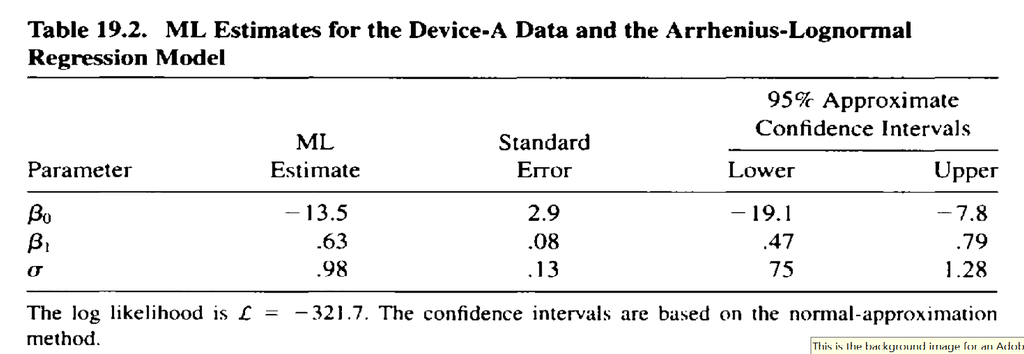

fig1

En Sas se escribió el siguiente codigo

```r
#data classb;
 #  input hours censor count temp;
  # if _n_ = 1 then cntrl=1;
   #else cntrl=0;
   #label hours='Hours';
   #datalines;
#5000 1 30 10
#1298 0 1 40
#1390 0 1 40
#3187 0 1 40
#3241 0 1 40
#3261 0 1 40
#3313 0 1 40
#4501 0 1 40
#4568 0 1 40
#4841 0 1 40
#4982 0 1 40
#5000 1 90 40
#581  0 1 60
#925  0 1 60
#1432 0 1 60
#1586 0 1 60
#2452 0 1 60
#2734 0 1 60
#2772 0 1 60
#4106 0 1 60
#4674 0 1 60
#5000 1 11 60
#283 0 1 80
#361 0 1 80
#515 0 1 80
#638 0 1 80
#854 0 1 80
#1024 0 1 80
#1030 0 1 80
#1045 0 1 80
#1767 0 1 80
#1777 0 1 80
#1856 0 1 80
#1951 0 1 80
#1964 0 1 80
#2884 0 1 80
#5000 0 1 80
#;

#proc reliability;
   #distribution lognormal;
   #freq count;
   #model hours*censor(1) = temp /
    #  relation = arr2
     # obstats(quantile = 0.0001 .5 .9 control = cntrl;
   #rplot hours*censor(1) = temp /
    #  pplot
     # fit = model
      #noconf
      #relation = arr2
      #plotdata
      #plotfit 80 60 40 10
#;
#run;
```

y se obtuvo la siguiente salida

[figure not shown]

fig1

3. ¿Cuál sería la proporción de fallas en condiciones de operación normal a las 25000 horas?

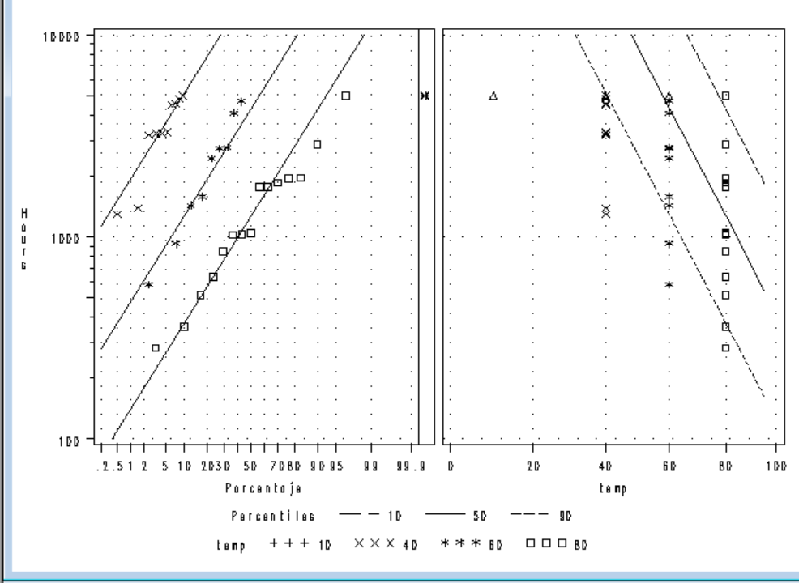

fig1